# What Songs tell us about?

Haoyu Zhang(hz2563)

[figure not shown]

“What Songs tell us about”

### Load the processed lyrics data along with artist information

We use the processed data and artist information for our analysis.

## How about these songs?

In order to get some basic characteristics of songs, the length of each song and the readability of lyrics would be analyzed in this part.

#### Length of lyrics

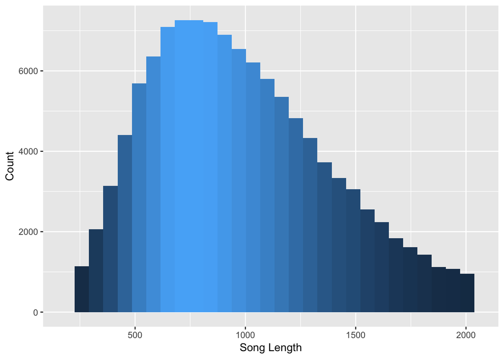

#### Readability

I also did a readability test for the sample of 20000 lyrics, here I used Flesch-Kincaid grade level to be my measure, which indicates how difficult a passsage in English is to understand. \ The grade level is calculated with the following formula:
$$\text{Flesch-Kincaid} = 0.39(\frac{\text{total words}}{\text{total sentences}})+11.8(\frac{\text{total Syllabus}}{\text{total words}})-15.59$$

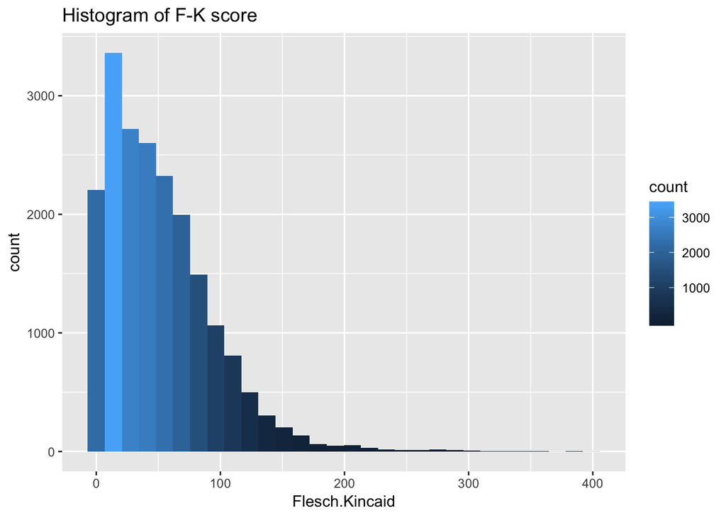

## Word Frequency

#### To investigate the most frequent words used in song lyrics, I first plot top 10 frequent words in songs.

Then I did 2 wordclouds to have a clear picture of the word frequency.

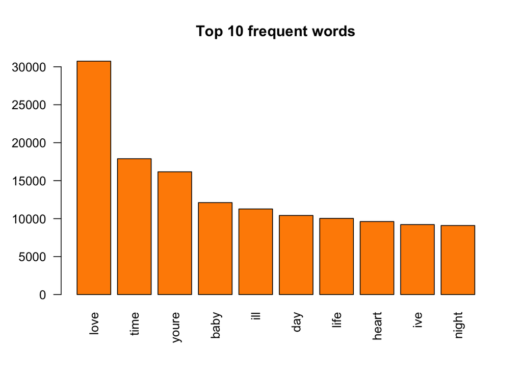

```
##  love  time youre  baby   ill   day  life heart   ive night
## 30736 17892 16167 12114 11276 10420 10032  9617  9216  9096
```

[interactive chart not shown]

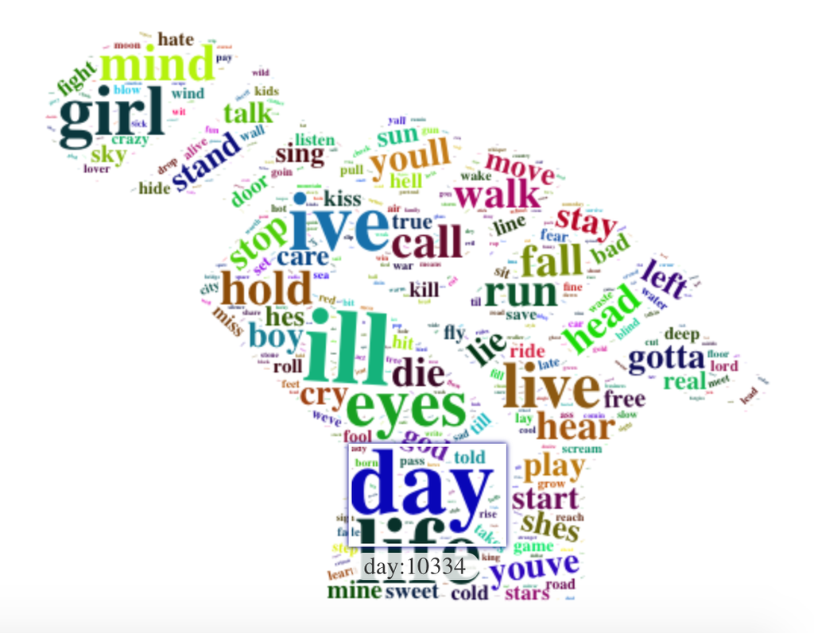

Then, let’s dive into specific genres of songs to see if there is any commonality or difference between different genres. Here I picked *Rock* and *Pop*, which the most common two genres among the data.\

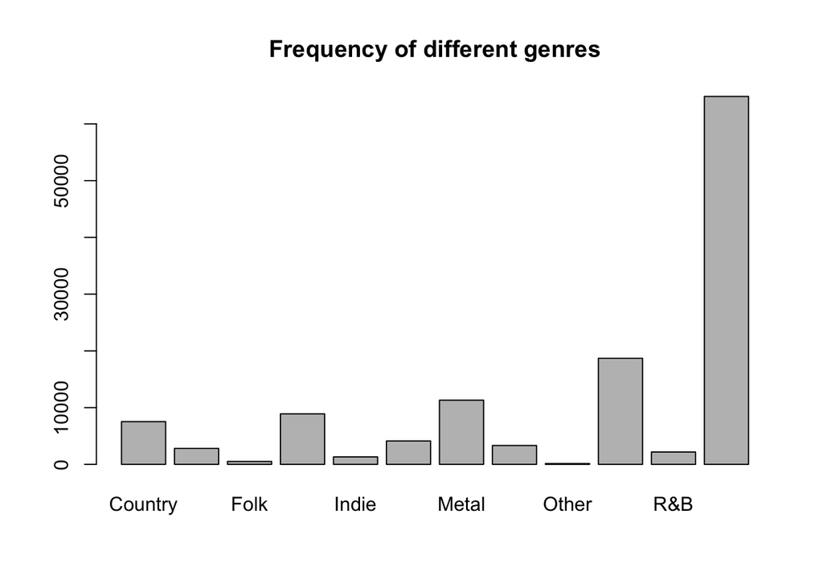

First, let’s look at the rock. I plot the most frequently appeard words in rock lyrics.

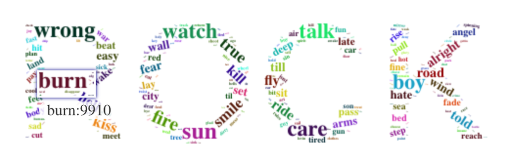

Then, let’s have a look at the word cloud of pop lyrics.

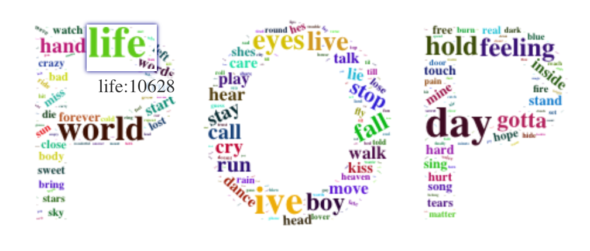

After comparing individual genres, let’s take a look at the comparison plots.

As we can see from the commonality plot, both *Rock* and *Pop* love to sing the song about “Love”, “You”, “Time”.

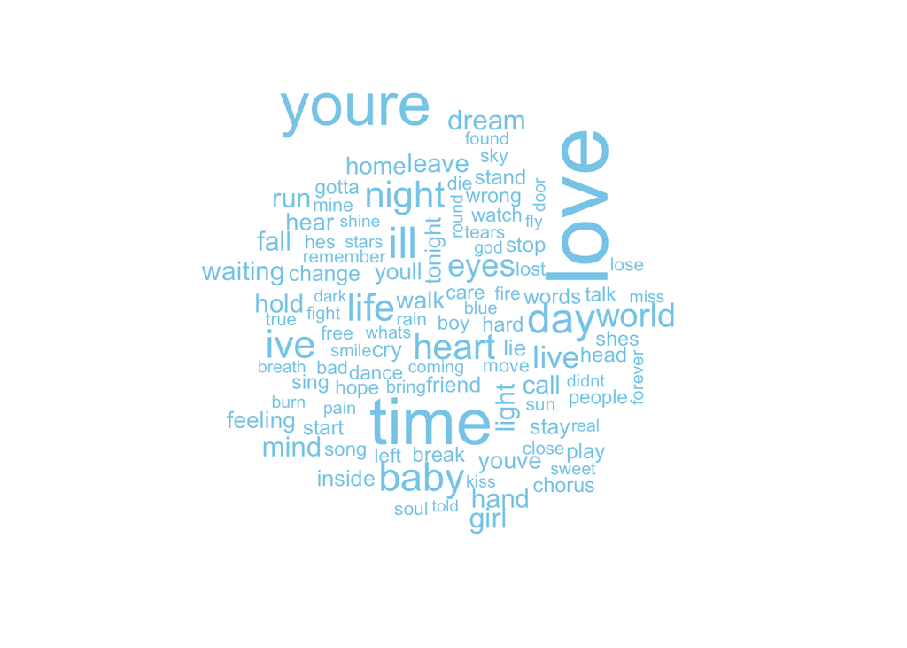

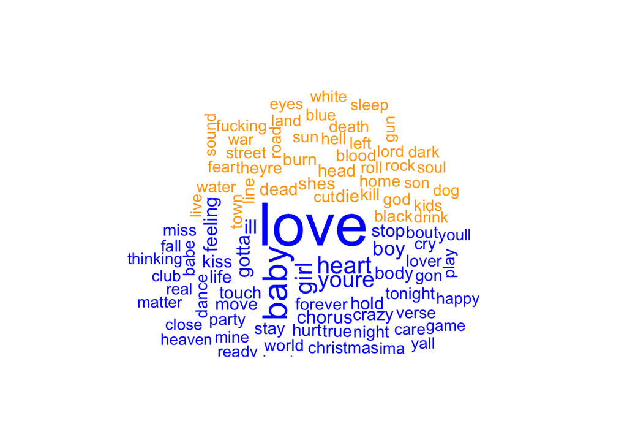

[figure not shown]

```
## [1] 5.1 4.1 4.1 2.1
```

```
##  [1] time  youre love  day   ive   ill   life  night eyes  live
## Levels: day eyes ill ive life live love night time youre
```

## Summary

#### As we can see from the plots, most frequent words used in Songs like POP and Rock is always about “Love”, focusing on “You”, and “I’ll” do that for you in my whole “life” every“Day”, but probabliy only in “Night” XD.

[figure not shown]

“What Songs tell us about”